# R Training

# 1 Welcome to the course!

This won’t be your standard classroom course where we formally teach you. Instead we will guide you through some things that we know and give you a chance to practice. Our aim is for you to feel confident from being able to write one line of code to calling yourself a proper researcher.

If you have questions, ask. If you need someone to slow down or say it in a different way (comme le français), then say so. Because if you’re thinking it, someone else probably is too.

Follow along the next pages to get your computer up and running, and if you see a box, like the one below,

```r
be sure to type everything that you see in these boxes onto your own computer.
```

This course is about seeing **and doing**. Don’t only read it. Do it.

Now that the formalities are out of the way… Buckle up, and let’s learn how to work with data.

# I Pre-Training Material

# 2 Setting up your computer

It’s time to set up your system. Ready? Let’s go.

Let’s get the right programs installed on your computer. Then we will explain what they are and why you need them.

**First, download and install `R`:**

Go to the following website, click the *Download* button, and follow the website’s instructions from there. https://mirrors.nics.utk.edu/cran/

**Second, download and install `RStudio`:**

Go to the following website and choose the free Desktop version: https://rstudio.com/products/rstudio/download/

**Third, make sure `RStudio` opens successfully:**

Open the `RStudio` app. A window should appear that looks like this:

[figure not shown]

**Fourth, make sure `R` is running correctly in the background:**

In `RStudio`, in the pane on the left (the “Console”), type 2+2 and hit Enter.  
If `R` is working properly, the number “4” will be printed in the next line down.

[figure not shown]

**Finally, some minor adjustments to make `RStudio` run smoother (and look cooler):**

[figure not shown]

Specifically, **uncheck** the option under *Workspace* to ‘Restore .RData into workspace at startup.’

Now go to the `Appearance` settings and choose a cool theme!

[figure not shown]

**Boom!** You’ve got R up and running. Now it’s time to install some packages.

## Install packages

Packages are what makes R so great. To install a package, open Rstudio, make sure you’re connected to Wi-Fi, and type the following code into the “Console” in the bottom left

```r
install.packages('packagename')
```

Did that work? Probably not, because “packagename” is not a real R package. The packages we’ll be using are the following:

```
tidyverse
RColorBrewer
leaflet
ggthemes
rmarkdown
sp
```

To install all of these, you can run `install.packages` for each package:

```r
install.packages('tidyverse')
install.packages('RColorBrewer')
# etc., etc.
```

So, now you’ve got R, RStudio, and some cool packages. Good job. You’re ready for the next module.

# 3 Preparing for the R Training

#### Learning goals

- Learn how to run code in R
- Learn how to use R as a calculator
- Learn how to use mathematical and logical operators in R

When you open `RStudio`, you see several different panes within the program’s window. You will get a tour of `RStudio` in the next module. For now, look at the left half of the screen. You should see a large pane entitled the *Console*.

[figure not shown]

`RStudio`’s *Console* is your window into `R`, the engine under the hood. The *Console* is where you type commands for `R` to run, and where `R` prints back the results of what you have told it to do. Think of the *Console* as a chatroom, where you and `R` talk back and forth.

## Running R code in the *Console*

Type your first command into the *Console*, then press `Enter`:

```r
1 + 1
[1] 2
```

When you press `Enter`, you send your line of code to `R`; you post it for `R` to see. Then `R` takes it, does some processing, and posts a result (`2`) just below your command.

Note that spaces don’t matter. Both of the following two commands are legible to `R` and return the same thing:

```r
4+4
[1] 8
```

```r
4        +        4
[1] 8
```

However, it is better to make your code as easy to read as possible, which usually means using a single space between numbers:

```r
4 + 4
[1] 8
```

Try typing in other basic calculations:

## Use R like a calculator

As you can tell from those commands you just ran, `R` is, at heart, a fancy calculator.

Some calculations are straightforward, like addition and subtraction:

```r
490 + 1000
[1] 1490
```

```r
490 - 1000
[1] -510
```

Division is pretty straightforward too:

```r
24 / 2
[1] 12
```

For multiplication, use an asterisk (`*`):

```r
24 * 2
[1] 48
```

You denote exponents like this:

```r
2 ^2
[1] 4
```

```r
2 ^3
[1] 8
```

```r
2 ^4
[1] 16
```

Finally, note that `R` is fine with negative numbers:

```r
9 + -100
[1] -91
```

## Getting along with `R`

### Re-running code in the Console

If you want to re-run the code you just ran, or if you want to recall the code so that you can adjust it slightly, click anywhere in the *Console* then press your keyboard’s `Up` arrow.

If you keep pressing your `Up` arrow, `R` will present you with sequentially older commands. `R` keeps a history of everything you have said to it since you opened this window.

If you accidentally recalled an old command without meaning to, you can reset the *Console*’s command line by pressing `Escape`.

### Incomplete commands

Similar to talking to a friend, if you start a sentence and don’t finish it, your friend will get confused. `R` gets confused when you enter an incomplete command, and will wait for you to write the remainder of your command on the next line in the *Console* before doing anything.

For example, try running this code in your *Console*:

```r
45 -
```

You will find that `R` gives you a little `+` sign on the line under your command, which means it is waiting for you to complete your command.

Or, if instead you want `R` to stop waiting and stop running, just press the `Escape` key.

### Getting errors

`R` only understands your commands if they follow the rules of the `R` language (often referred to as its *syntax*). If `R` does not understand your code, it will throw an error and give up on trying to execute that line of code.

For example, try running this code in your *Console*:

```r
4 + y
```

You probably received a message in red font stating: `Error: object 'y' not found`. That is because `R` did know how to interpret the symbol `y` in this case, so it just gave up.

**Get used to errors!** They happen all the time, even (especially?) to professionals, and it is essential that you get used to reading your own code to find and fix its errors.

Here’s another piece of code that will produce an error:

```r
dfjkltr9fitwt985ut9e3
```

### Using parentheses

`R` is usually great about following classic rules for Order of Operations, and you can use parentheses to exert control over that order. For example, these two commands produce different results:

```r
2*7 - 2*5 / 2
[1] 9
```

```r
(2*7 - 2*5) / 2
[1] 2
```

Note that parentheses need to come in pairs: whenever you type an open parenthesis, `(`, eventually you need to provide a corresponding closed parenthesis, `)`.

The following line of code will return a plus sign, `+`, since `R` is waiting for you to close the parenthetical before it processes your command:

```r
4 + (5
```

Remember: **parentheses come in pairs!** The same goes for other types of brackets: `{...}` and `[...]`.

### Using operators in R

You can ask `R` basic questions using *operators*.

For example, you can ask whether two values are equal to each other.

```r
96 == 95
[1] FALSE
```

```r
95 + 2 == 95 + 2
[1] TRUE
```

`R` is telling you that the first statement is `FALSE` (`96` is not, in fact, equal to `95`) and that the second statement is `TRUE` (`95 + 2` is, in fact, equal to itself).

**Note the use of *double* equal signs here.** You must use two of them in order for `R` to understand that you are asking for this logical test.

You can also ask if two values are *NOT* equal to each other:

```r
96 != 95
[1] TRUE
```

```r
95 + 2 != 95 + 2
[1] FALSE
```

This test is a bit more difficult to understand: In the first statement, `R` is telling you that it is `TRUE` that `96` is different from `95`. In the second statement, `R` is saying that it is `FALSE` that `95 + 2` is not the same as itself.

Note that `R` lets you write these tests another, even more confusing way:

```r
! 96 == 95
[1] TRUE
```

```r
! 95 + 2 == 95 + 2
[1] FALSE
```

The first line of code is asking `R` whether it is not true that `96` and `95` are equal to each other, which is `TRUE`. The second line of code is asking `R` whether it is not true that `95 + 2` is the same as itself, which is of course `FALSE`.

Other commonly used operators in `R` include greater than / less than symbols (`>` and `<`, also known as the *left-facing alligator* and *right-facing alligator*), and greater/less than or equal to (`>=` and `<=`).

```r
100 > 100
[1] FALSE
```

```r
100 >= 100
[1] TRUE
```

```r
(100 != 100) == FALSE
[1] TRUE
```

## Use built-in R functions

R has some built-in “functions” for common calculations, such as finding square roots and logarithms. Functions are packages of code that take a given value, transform it according to some internal code instructions, and provide an output. You will learn more about functions in a few modules.

To find the square-root of a number, use the ‘squirt’ command, `sqrt()`:

```r
sqrt(16)
```

Note the use of parentheses here. When you are calling a function, when you see parentheses, think of the word ‘of’. This line translates to ‘the square root of 16’. You are taking the sqrt of the number inside the parenthetical.

To get the log of a value:

```r
log(4)
```

Note that the function `log()` is the natural log function (i.e., the value that e must be raised to in order to equal 4). To calculate a base-10 logarithm, use `log10( )`.

```r
log(10)

log10(10)
```

Another handy function is round(), for rounding numbers to a specific number of decimal places.

```r
100/3

round(100/3)

round(100/3,digits=1)

round(100/3,digits=2)

round(100/3,digits=3)
```

Finally, R also comes with some built-in values, such as pi:

```r
pi
```

**Congratulations! You are all prepped for the R Training in Brazzaville. We will see you there.**

#### Other Resources

datascience.pizza

Hobbes Primer, Table 1 (Math Operators, pg. 18) and Table 2 (Logical operators, pg. 22)

# II Getting Started

# 4 Welcome!

#### Learning goals

- Learn what this course is about
- Learn about the why
- Start coding

## What this is, and what it isn’t

This is not a textbook or an encyclopedia. This is not a reference manual. It is not exhaustive or comprehensive.

**So what is this?** This guide is an *accelerator,* an *incubator* designed to guide you along the most direct path from your first line of code to becoming a capable researcher. Our goal is to help you through the most dangerous period in your data science education: your very first steps. The first three weeks. That is when 99% percent of people give up on learning to code.

But it doesn’t need to be this way.

This approach is based on three core premises:

**Premise 1: We learn best by doing.** Our goal is to get you *doing* data science. We will keep theory and detail to a minimum. We will give you the absolute basics, then offer you exercises and puzzles that motivate you to learn the rest. Then, once you’ve been *doing* data science for a bit, you soon begin *thinking* like a data scientist. By that, we mean tackling ambiguous problems with persistence, independence, and creative problem solving.

**Premise 2: We learn best with purpose.** Once you gain comfort with the basic skills, you will be able to start working on real data, for real projects, with real impact. You will start to *care about what you are coding*. And that is when the learning curve *skyrockets* – because you are motivated, and because you are learning *reactively*, instead of preemptively. Our goal is to get you to the point of take-off as quickly as possible.

**Premise 3: A simple toolbox is all you need to build a house.** Once you become comfortable with a few basic coding tools, you can build pretty much anything. The toolbox doesn’t need to be that big; if you know how to use your tools well, and if you have enough building supplies (i.e., data), the possibilities are limitless.

**One more thing that this is not:** This is not a fancy interactive tutorial with bells or whistles. We purposefully designed this to be simple and “analog”. You will not be typing your code into this website and getting feedback from a robot, or setting up an account to track your progress, or getting pretty merit badges or points when you complete each module.

Instead, you will be doing your work on your *own machine*, working with *real folders and files*, downloading data and moving it around, etc. – all the things you will be doing as a real data scientist in the real world.

## What you will learn

- As you are learning to code, we will sprinkle in conceptual foundations and motivations for this work: what data science is, why it matters, and ethical issues surrounding it: the good, the bad, and the ugly. The most important thing, at first, is to start writing code.
- The entire point of this course is to learn how to use `R` (in `RStudio`). Here you will add the first and most important tools to your toolbox: working with variables, vectors, dataframes, scripts, and file directories.
- You will gain the skills to bring in your own data and work with it in `R`. You will learn how to produce beautiful plots and how to reorganize, filter, and summarize your datasets. You will also learn how to conduct basic statistics, from exploratory data analyses (e.g., producing and comparing distributions) to significance testing.
- If and when you conquer all of the above, we will provide various puzzles that allow you to apply the basic `R` skills from the previous unit to fun questions and scenarios. In each of these exercises, questions are arranged in increasing order of difficulty, so that beginners will not feel stuck right out of the gate, nor will experienced coders become bored. This is where you really begin to cut your teeth on real-world data puzzles: figuring out how to use the `R` tools in your toolbag to tackle an ambiguous problem and deliver an excellent data product.

## Where did this come from

This curriculum was modified based on a curriculum originally developed for the [**DataLab**](https://new.sewanee.edu/sewanee-datalab/) at Sewanee: The University of the South, TN, USA. Thanks Databrew, Eric Keen, Joe Brew, Ben Brew, and Matthew Rudd.

# 5 Using `RStudio` & `R` scripts

#### Learning goals

- Understand the difference between `R` and `RStudio`
- Understand the `RStudio` working environment and window panes
- Understand what `R` scripts are, and how to create and save them
- Understand how to add comments to your code, and why doing so is important
- Understand what a *working directory* is, and how to use it
- Learn basic project work flow

## `R` and `RStudio`: what’s the difference?

These two entities are similar, but it is important to understand how they are different.

In short, `R` is a open-source (i.e., free) coding language: a powerful programming engine that can be used to do really cool things with data.

`R Studio`, in contrast, is a free *user interface* that helps you interact with `R`. If you think of `R` as an engine, then it helps to think of `RStudio` as the car that contains it. Like a car,`RStudio` makes it easier and more comfortable to use the engine to get where you want to go.

`R Studio` needs `R` in order to function, but `R` can technically be used on its own outside of `RStudio` if you want. However, just as a good car mechanic can get an engine to run without being installed within a car, using `R` on its own is a bit clunky and requires some expertise. For beginners (and everyone else, really), `R` is just so much more pleasant to use when you are operating it from within `RStudio`.

`RStudio` also has increasingly powerful *extensions* that make `R` even more useful and versatile in data science. These extensions allow you to use `R` to make interactive data dashboards, beautiful and reproducible data reports, presentations, websites, and even books. And new features like these are regularly being added to `RStudio` by its all-star team of data scientists.

That is why this book *always* uses `RStudio` when working with `R`.

## Two-minute tour of `RStudio`

When you open `RStudio` for the first time, you will see a window that looks like the screenshot below.

[figure not shown]

### Console

You are already acquainted with `RStudio`’s *Console*, the window pane on the left that you use to “talk” to `R`. (See Preparing for R Training Module.)

### Environment

In the top right pane, the *Environment*, `RStudio` will maintain a list of all the datasets, variables, and functions that you are using as you work. The next modules will explain what variables and functions are.

### Files, Plots, Packages, & Help

You will use the bottom right pane very often.

- The **Files** tab lets you see all the files within your **working directory**, which will be explained in the section below.
- The **Plots** tab lets you see the plots you are producing with your code.
- The **Packages** tab lets you see the *packages* you currently have installed on your computer. Packages are bundles of `R` functions downloaded from the internet; they will be explained in detail a few modules down the road.
- The **Help** tab is very important! It lets you see *documentation* (i.e., user’s guides) for the functions you use in your code. Functions will also be explained in detail a few modules down the road.

These three panes are useful, but the most useful window pane of all is actually *missing* when you first open `RStudio`. This important pane is where you work with **scripts**.

## Scripts

Before explaining what scripts are and why they are awesome, let’s start a new script.

**To start a new script,** go to the top left icon in the `RStudio` window, and click on the green plus sign with a blank page behind it:

[figure not shown]

A dropdown window will appear. Select “R Script”.

A new window pane will then appear in the top left quadrant of your `RStudio` window:

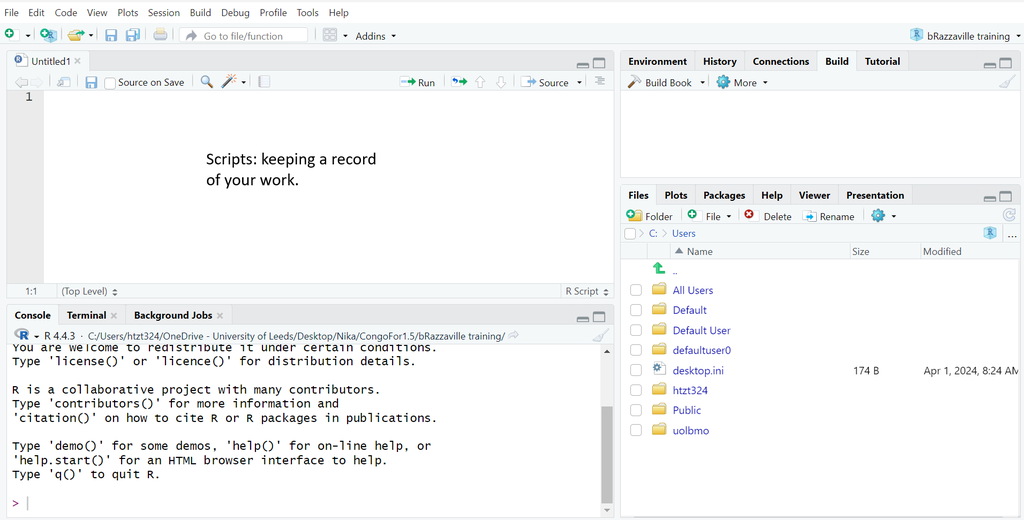

You now have a blank script to work in!

Now type some simple commands into your script:

```r
2  + 10
16 * 32
```

Notice that when you press `Enter` after each line of code, nothing happens in the *Console*. In order to send this code to the Console, press `Enter + Command` at the same time (or `Enter + Control`, if you are on Windows) for each line of code.

To send both lines of code to the *Console* at once, select both lines of code and hit `Enter + Command`.

(To select multiple lines of code, you can (1) click and drag with your mouse or (2) hold down your `Shift` key while clicking your down arrow key. To select *all* lines of code, press `Command + A`.)

So let’s build up this script. Add a few more lines to your script, such that your script now looks like this.

```r
2  + 10
16 * 32
1080 / 360
500 - 600
```

Run all of these lines of code at once.

Now add `10` to the first number in each row, and re-run all of the code.

Think about how much more efficient part (B) was thanks to your script! If you had typed all of that directly into your *Console*, you would have to recall or retype each line individually. That difference builds up when your number of commands grows into the hundreds.

### What is an `R` script, and why are scripts so awesome?

An `R` script is a file where you can keep a record of your code. Just as a script tells actors exactly what to say and when to say it, an `R` script tells `R` exactly what code to run, and in what order to run it.

When working with R, you will almost always type your code into a script first, *then* send it to the *Console*. You can run your code immediately using `Enter + Command`, but you also have a script of what you have done so that you can run the exact same code at a later time

To understand why `R` scripts are so awesome, consider a typical workflow in *Excel* of *GoogleSheets*. You open a big complicated spreadsheet, spend hours making changes, and save your changes frequently throughout your work session.

The main disadvantages of this workflow are that:

1. There is no detailed record of the changes you have made. You cannot prove that you have made changes correctly. You cannot pass the original dataset to someone else and ask them to revise it in the same way you have. (Nor would you want to, since making all those changes was so time-consuming!) Nor could you take a different dataset and guarantee that you are able to apply the exact same changes that you applied to the first. In other words, your work is not reproducible.
2. Making those changes is labor-intensive! Rather than spend time manually making changes to a single spreadsheet, it would be better to devote that energy to writing `R` code that makes those changes for you. That code could be run in this one case, but it could also be run at any later time, or easily modified to make similar changes to other spreadsheets.
3. Unless you are an advanced *Excel* programmer, you are probably modifying your original dataset, which is always dangerous and a big No-No in data science. Each time you save your work in *Excel* or *GoogleSheets* (which automatically saves each change you make), the original spreadsheet file gets replaced by the updated version. But if you brought your dataset into `R` instead, and modified it using an `R` script, then you leave the raw data alone and keep it safe. (Sure, you can always save different versions of your Excel file, but then you run the risk of mixing up versions and getting confused.)

Working with `R` scripts allows you to avoid all of these pitfalls. When you write an `R` script, you are making your work ….

- **Efficient.** Once you get comfortable writing `R` code, you will be able to write scripts in a few minutes. Those scripts can modify datasets within seconds (or less) in ways that would take hours (or years) to carry out manually in *Excel* or *GoogleSheets*.
- **Reproducible.** Once you have written an`R` script, you can reproduce your own work whenever you want to. You can send your script to a colleague so that they can reproduct your work as well. Reproducible work is defensible work.
- **Low-risk.** Since your R script does not make any changes to the original data, you are keeping your data safe. It is *essential* to preserve the sanctity of raw data!

Note that there is nothing fancy or special about an `R` script. An `R` script is a simple text file; that is, it only accepts basic text; you can’t add images or change font style or font size in an `R` script; just letters, numbers, and your other keyboard keys. The file’s extension, `.R` tells your computer to interpret that text as `R` code.

### Commenting your code

Another advantage of scripts is that you can include *comments* throughout your code to explain what you are doing and why. A *comment* is just a part of your script that is useful to you but that is ignored by `R`.

To add comments to your code, use the hashtag symbol (`#`). Any text following a `#` will be ignored by `R`.

```r
# Define variable x
x <- 2
x

# Make a new variable, y, based on x
y <- x*56

z <- y / 23 # Make a third variable, z, based on y

x + y + z # Now get the sum of all three variables
```

Adding comments can be more work, but in the end it saves you time and makes your code more effective. Comments might not seem necessary in the moment, but it is amazing how helpful they are when you come back to your code the next day. Frequent and helpful comments make the difference between good and great code. Comment early, comment often!

You can also use lines of hashtags to visually organize your code. For example:

```r
##############################################
# Setup
##############################################

# Define variable x
x <- 2
x

# Make a new variable, y, based on x
y <- x*56

z <- y / 23 # Make a third variable, z, based on y


##############################################
# Get result
##############################################

x + y + z # Now get the sum of all three variables
```

This might not seem necessary with a 5-line script, but adding visual breaks to your code becomes immensely helpful when your code grows to be hundreds of lines long.

### Saving your work

**`R` scripts are only useful if you save them!** Unlike working with *GoogleDocs* or *GoogleSheets*, `R` will not automatically save your changes; you have to do that yourself. (This is inconvenient, but it is also safer; most of coding is trial and error, and sometimes you want to be careful about what is saved.)

**Step 1: Decide where to save your work.** The folder in which you save your `R` script will be referred to as your *working directory* (see the next section). For the sake of these tutorials, it will be most convenient to save all of your scripts in a single folder that is in an easily accessed location.

**Step 2: In that location, make a new folder named `bRazzaville`**: We suggest making a new folder on your Desktop and naming it `bRazzaville`, but you can name it whatever you want and place it wherever you want.

**Step 3: Save your script in that folder** To save the script you have opened and typed a few lines of code into, press `Command + S` (or `Control + S`). Alternatively, go to File > Save. Navigate to the folder you just created and type in a file name that is simple but descriptive. We suggest making a new `R` script for each module, and naming those scripts according to each module’s name. In this case, we recommend naming your script `intro_to_scripts`.

(It is good practice to avoid spaces in your file names; it will be essential later on, so good to begin the correct habit now. Start using an underscore, `_`, instead of a space.)

## Your working directory

When you work with data in `R`, `R` will need to know where in your computer to look for that data. The folder it looks in is known as your **working directory**.

To find out which folder `R` is currently using as your working directory, use the function `getwd()`:

```r
getwd()
[1] "C:/Users/htzt324/OneDrive - University of Leeds/Desktop/Nika/CongoFor1.5/Git/cbsi_r_training"
```

Almost always, you want to set your working directory to the folder your `R` script is in.

### How to set your working directory

Whenever you begin a new `R` script, setting your working directory will be one of the first things you do.

There are three ways to set your working directory:

1. **Manually without code.** On the top banner in `RStudio`, go to *Session > Set Working Directory > To Source File Location*:

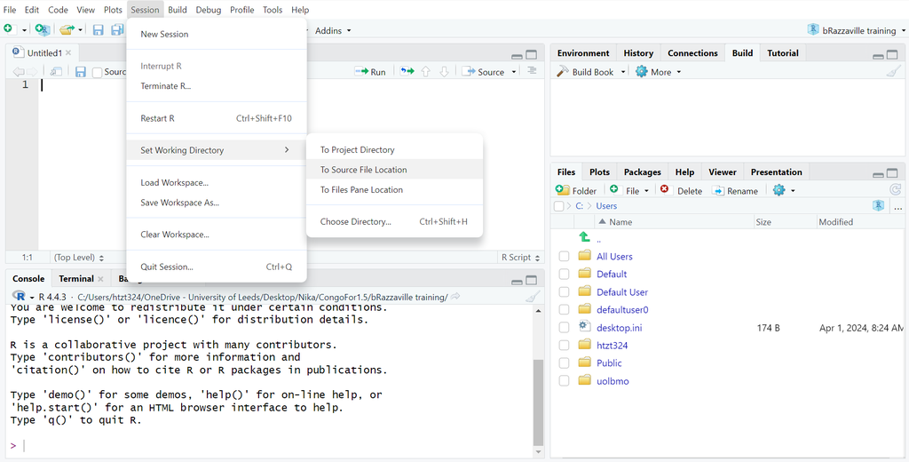

This action sets your working directory to the same folder that your `R` script is in. When you do this, you will see that a command has been entered into your *Console*:

```r
setwd("~/Desktop/bRazzaville")
```

(Note that the filepath may be different on your machine.) This code is using the function `setwd()`, which is also used in the next option. Go ahead and copy this `setwd(...)` code and paste it into your script, so it will be easy to use next time.

2. **Manually with code, using `setwd()`**: You can manually provide the filepath you want to set as your working directory. This option allows you to set your `wd` to whatever folder you want. The character string within the `setwd()` command is the path to a folder. The formatting of this string must be exact, otherwise `R` will throw an error. Use option 1 at first to get a sense of how your computer formats its folder paths. Copy, paste, and modify the output from option 1 in order to type your path correctly.
3. **Automatically with code**: There is a command you can run that automatically sets your working directory to the folder that your `R` script is in. This is the most efficient and useful method, in our experience.

To use this command, you must first install a new package. Run this code:

```r
install.packages("rstudioapi")
library(rstudioapi)
```

For now, you do not need to understand what this code is doing. We will explain packages and the `library()` function in a later module.

You can now copy, paste, and run this code to set your working directory automatically:

```r
setwd(dirname(rstudioapi::getActiveDocumentContext()$path))
```

This is a complicated line of code that you need not understand. As long as it works, it works! Confirm that `R` is using the correct working directory with the command `getwd()`.

## Typical workflows

Now that you know how to create a script and set your working directory, you are prepared to work on data projects in `RStudio`.

The workflow for beginning a new data project typically goes like this:

*In your file explorer…*

1. **Create a folder for your project** somewhere on your computer. This will become your working directory.
2. **Create subfolders** within your working directory, if you want. We recommend creating a `data` subfolder, for keeping data, and a `z` subfolder, for keeping miscellaneous documents. The goal is to keep your working directory visually simple and organized; ideally, the only files not within subfolders are your `R` scripts.
3. **Add data** to your working directory, if you have any.

*In `RStudio` …*

4. **Create a new `R` script.**
5. **Save it** inside your intended working directory.
6. At the top of your script, use comments to **add a title, author info, and brief description.**
7. Add the code to **set your working directory.**
8. **Begin coding!**

### Template `R` script

Here is a template you can use to copy and paste into each new script you create:

```r
################################################################################
# < Add title here >
################################################################################
#
# < Add brief description here >
#
# < Author >
# Created on <add date here >
#
################################################################################
# Set working directory
setwd(dirname(rstudioapi::getActiveDocumentContext()$path))

################################################################################
################################################################################
# Code goes here





################################################################################
# (end of file)
```

#### Exercises

**1** *(if not already complete)*. Create a working directory for this course. Call it whatever you like, but `bRazzaville` could work great. Place it somewhere convenient on your computer, such as your Desktop.

**4.** Now make a copy of `template.R` to stage a script that you can use in the next module. To do so, in `RStudio` go to the top banner and click `File > Save As`. Save this new script as `variables.R` (because the next module is called *Variables in `R`*).

**5.** Modify the code in `variables.R` so that you are prepared to begin the next module. Change the title, and look ahead to the next module to fill in a brief description. Don’t forget to add your name as the author and specify today’s date.

Boom!

#### Other Resources

[A Gentle Introduction to `R` from the `RStudio` team](https://www.rstudio.com/resources/webinars/a-gentle-introduction-to-tidy-statistics-in-r/)

# 6 Review your R Training Prep

Prior to arriving in Brazzaville, we asked that you download R and RStudio and do some preparatory work. Let’s work through some of that information together.

#### Exercises

**Use `R` like a calculator**

**1.** Type a command in the *Console* to determine the sum of 596 and 198.

**2.** Re-run the sum of 596 and 198 without re-typing it.

**3.** Recall the command again, but this time adjust the code to find the sum of 596 and 298.

**4.** Practice escaping an accidentally called command: recall your most recent command, then press the right key to clear the *Console*’s command line.

**Recalling commands**

**5.** Find the sum of the ages of everyone in your immediate family.

**6.** Now recall that command and adjust it to determine the *average* age of the members of your family.

**7.** Find the square root of *pi* and round the answer to the 2 decimal places.

**Finding errors**

**8.** This line of code won’t run; instead, `R` will wait for more with a `+` symbol. Find the problem and re-write the code so that it works.

```r
5 * 6 +
```

**9.** The same goes for this line of code. Fix it, too.

```r
sqrt(16
```

**10.** This line of code will trigger an error. Find the problem and re-write the code so that it works.

```r
round(100/3,digits+3)
```

**11.** Type a command of your own into R that throws an error, then recall the command and revise so that `R` can understand it.

**Show that the following statements are TRUE:**

**12.** `pi` is greater than the square root of 9

**13.** It is FALSE that the square root of 9 is greater than `pi`

**14.** `pi` rounded to the nearest whole number equals the square root of 9

**Asking `TRUE` / `FALSE` questions**

**15.** Write and run a line of code that asks whether these two calculations return the same result:

```r
2*7 - 2*5 / 2
```

[output not shown]

```r
(2*7 - 2*5) / 2
[1] 2
```

**16.** Now write and run a line of code that asks whether the first calculation is larger than the second:

# 7 Data Visualization

#### Learning goals

- How to visualize data using `ggplot` (aka take data and make pretty pictures)
- How to save plots

## The importance of *data viz*

**Humans are wired to process information through pictures**. We can translate images into meaning with amazing speed.

Another way to say it; pictures communicate data. **This is why research and data visualization nearly always go hand in hand**.

The point here is that great data visualizations are not simply pretty. Much more importantly, they are effective too. They are the best means you have of conveying insights from your data to someone else.

Keep in mind that plots can be effective and misleading at the same time. There is a politics to plots and maps; they can have agendas, and they can manipulate viewers into interpreting the data in certain ways. So, it is incomplete for us to say simply that a good plot is an effective plot. Here’s a better definition: a good plot is one that is both effective and fair.

So, when you are viewing other people’s plots and making plots of your own, keep these five rules in mind:

1. A bad plot is an ineffective one, even if it is beautiful.
2. A good plot is an effective plot.
3. A great plot is one that is both effective and beautiful.
4. If you ever have to make a trade-off between effectiveness and beauty, sacrifice beauty.
5. Any plot that misleads or manipulates the viewer is bad, no matter how effective or beautiful it is.

Here is an excellent talk by the Egyptian data scientist, David McCandless, about the beauty of data visualization [(link here)](https://youtu.be/5Zg-C8AAIGg).

And this is a video that every person working with data visualizations should watch to get a sense of what can be done with data visualization and just how enthusiastic researchers get about data viz. Enjoy this video by the Swedish epidemiologist **Hans Rosling**, the pioneer of interactive data visualization [(link here)](https://www.youtube.com/watch?v=AdSZJzb-aX8).

## First steps to *data viz*

Do penguins with longer flippers weigh more or less than penguins with shorter flippers? What does the relationship between flipper length and body mass look like? Is it positive? Negative? Linear? Nonlinear? Does the relationship vary by species of the penguin? How about where the penguin lives?

Let’s create visualizations that we can use to answer these questions.